# mode speeds used in the ithim-global model

From the 11 cities we are working on, we selected cities with both trip duration and trip distances (4 in total: Sao Paulo, Vizag, Delhi and Bangalore) to calculate the default speeds.

- Delhi had stage distances and stage duration
- Bangalore had stage distances and stage duration
- Sao Paulo had only trip level infomation (trip distance and trip duration). In addition, it had walk to PT
- Vizag had only trip level data (not stages)

NB: Bangalore initialy had variable called transfer time = walk time plus wait time, but when we examined closely it matched the travel time. So in our data processing, we had used both variables to come up with trip duration.

## 1 First we explored the walk to PT time in the Sao Paulo data

### 1.1 Walk to/from PT box plots (Sao Paulo)

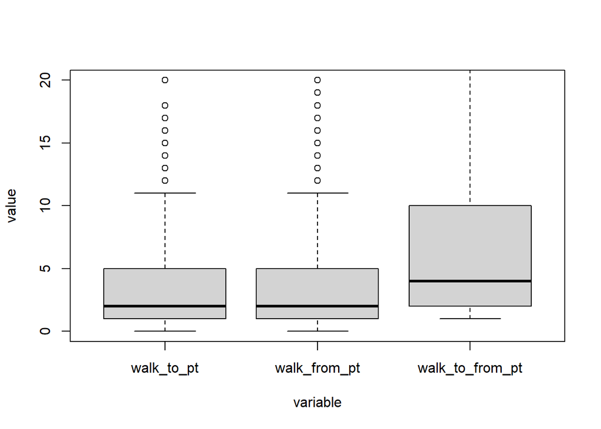

### 1.2 Walk to/from PT (Sao Paulo) - histogram shows skewedness

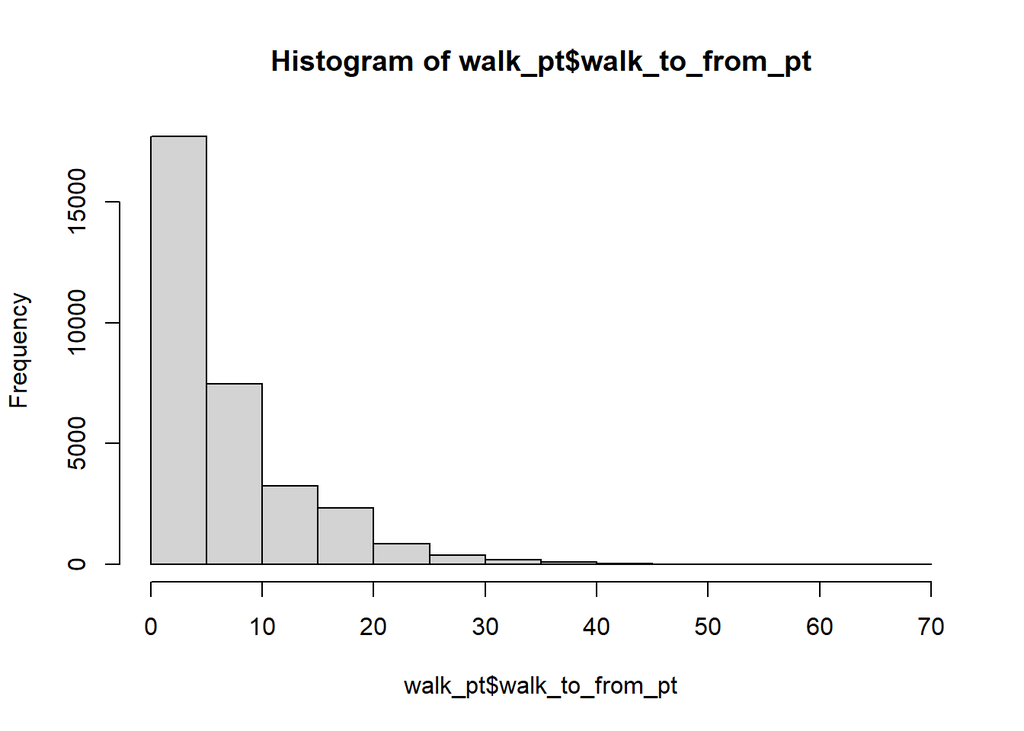

### 1.3 Walk to/from PT overall (Sao Paulo)

```
##    Min. 1st Qu.  Median    Mean 3rd Qu.    Max.
##   1.000   2.000   4.000   7.417  10.000  70.000
```

### 1.4 Walk to mode by mode (Sao Paulo) since all modes apart from walking had some walking component.

| trip_mode | median_walk_time |
| --- | --- |
| bicycle | 2 |
| bus | 10 |
| car | 2 |
| metro | 12 |
| motorcycle | 2 |
| other | 2 |
| taxi | 2 |
| train | 15 |
| van | 10 |

We applied the median walk time for bus to the Vizag dataset where we had only trip level data. It did not seem logical to apply walk to to all other modes because of the small value and because they are not likely to be captures as separate stage in trip survey.

## 2. We looked at the speeds for the different modes.

### 2.1 Walking speed did not vary much by city (Bangalore stood out though).

We agreed to set the same default waking speeds for all cities.

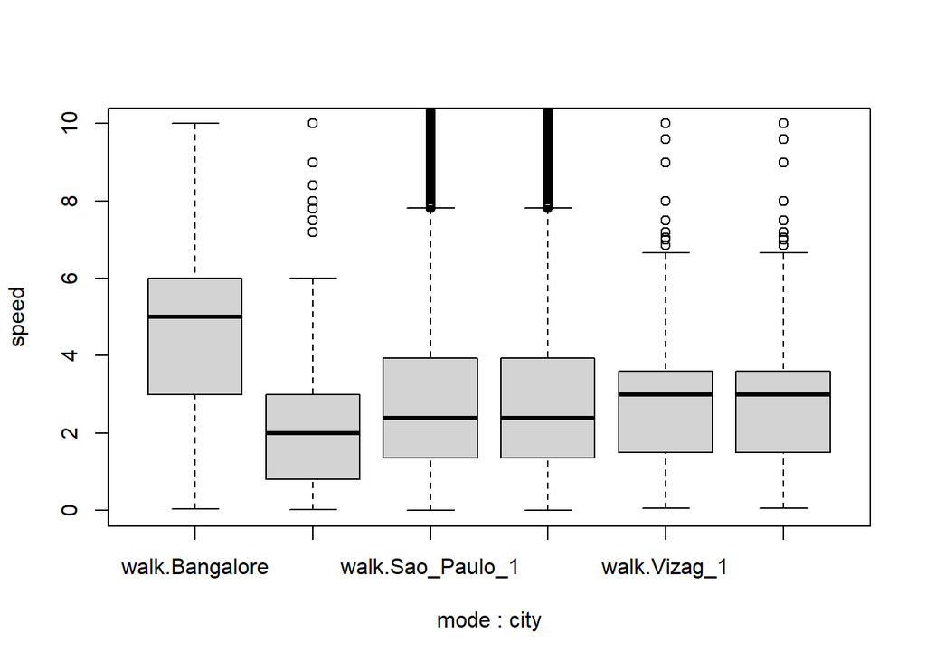

Walking speeds by sex and age only showed slight variations, and mostly so in Vizag. The variation by age was least pronounced, so our default walking speeds was split by sex.

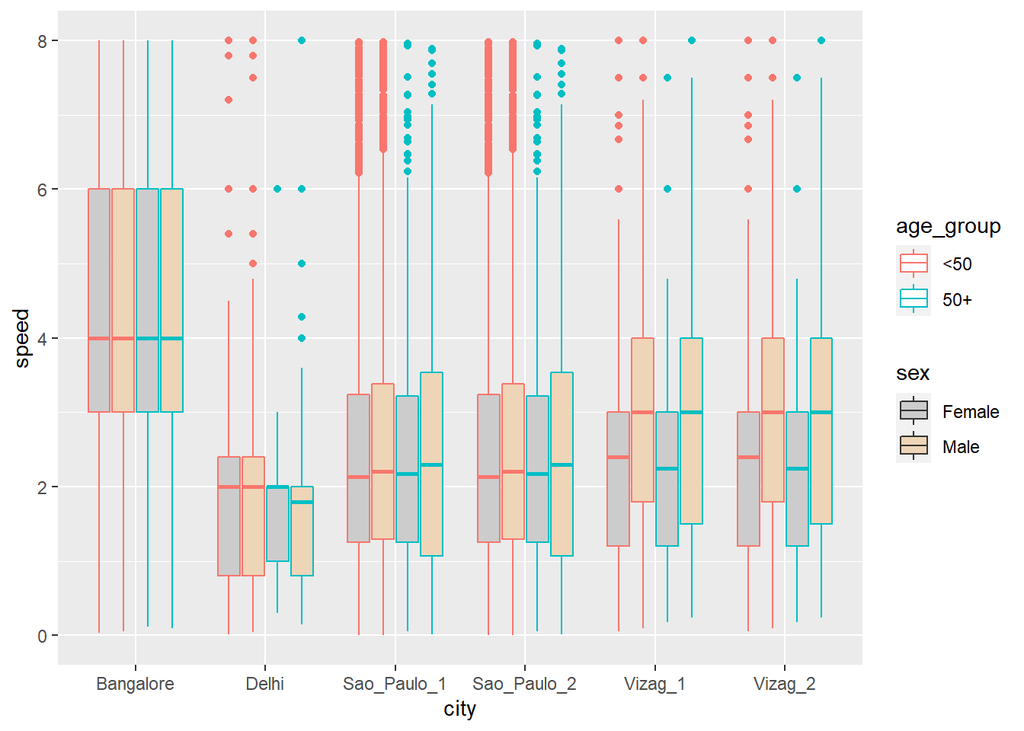

### 2.2 Cycling speeds did not seem to vary much across the cities

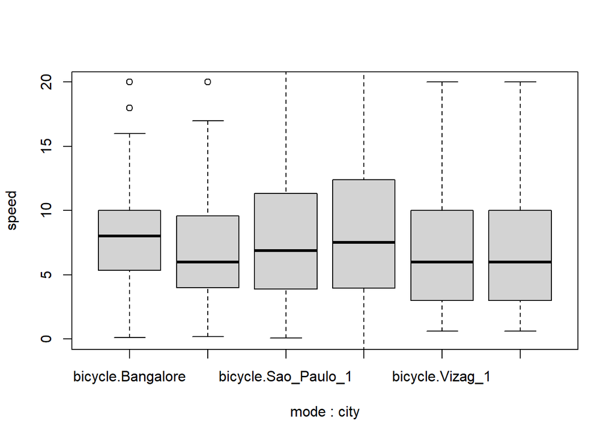

Cycling speed by sex and age showed variation in sex but not much by age, so we split default cycling speeds by sex.

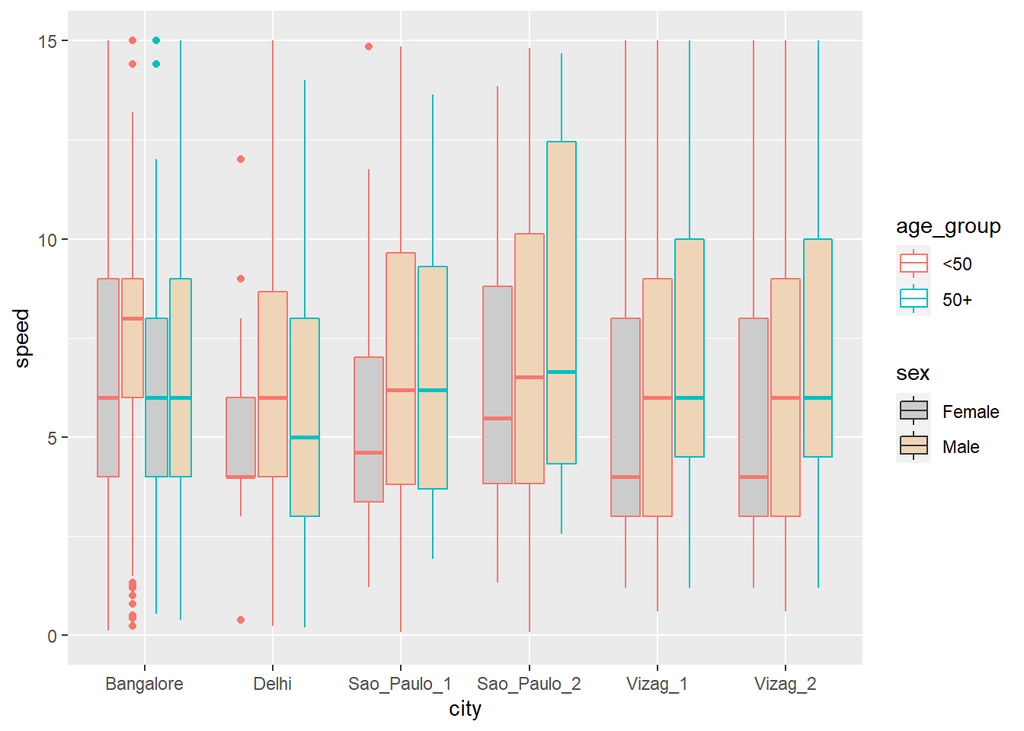

### 2.3 Motorcycle speed

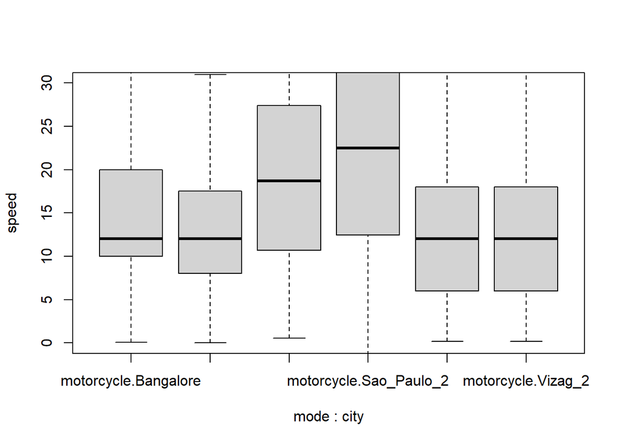

## 2.4 Car speeds

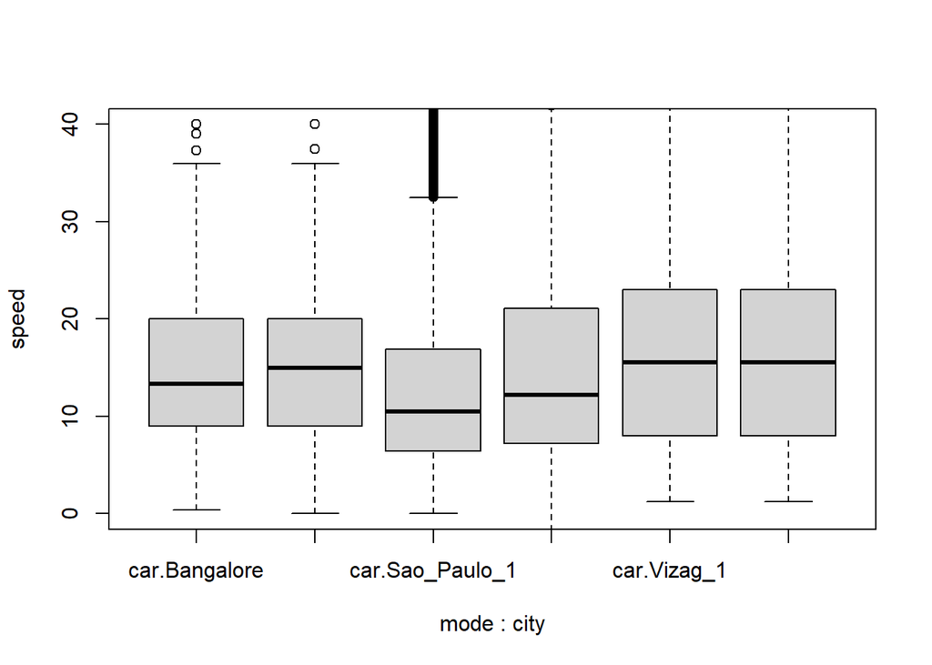

## 2.5 Bus speeds

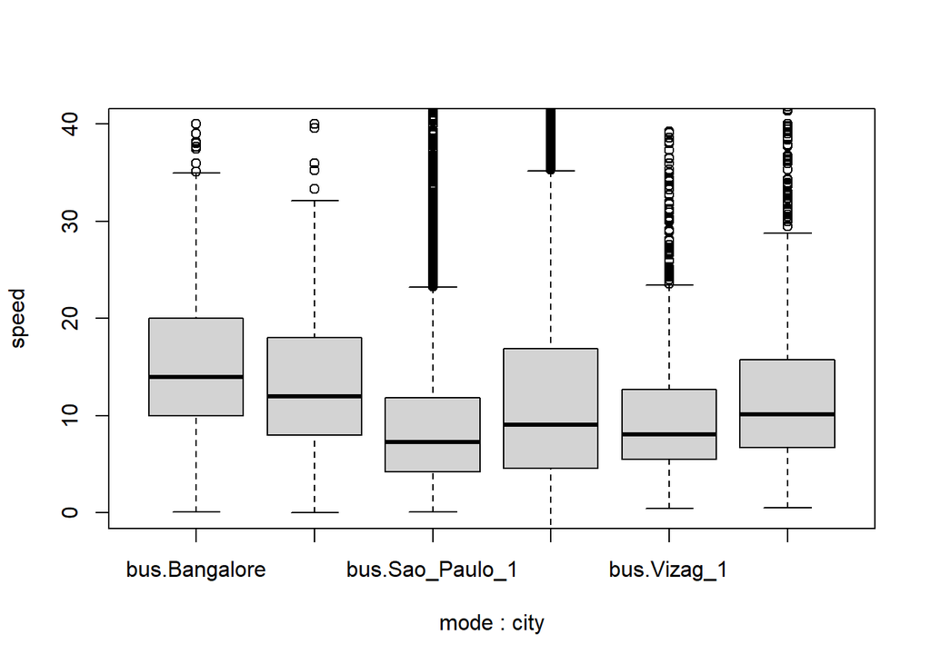

## 3. Conclusions on default speeds

- Walking: use median speeds for all cities split by sex
- Cycling: Use median speeds split by sex
- Cycled Rickshaw should be 2/3 the speed of bicycle
- Motorcycle Rickshaw should be 2/3 the speed of motorcycle
- Van should be the same as car
- Others: use same median speeds for both sex and age

| mode | sex | mode_speed |
| --- | --- | --- |
| bicycle | Female | 6.00000 |
| bicycle | Male | 8.00000 |
| walk | Female | 3.00000 |
| walk | Male | 4.00000 |
| bus | All | 12.00000 |
| car | All | 12.39862 |
| metro | All | 16.03689 |
| motorcycle | All | 12.00000 |
| other | All | 21.00000 |
| rickshaw | All | 12.00000 |
| taxi | All | 12.00000 |
| train | All | 17.05750 |
| van | All | 9.13680 |

### Adjsted speeds

default_speeds <- list( bus=10.8, bus_driver=10.8, minibus=10.8, minibus_driver=10.8, car=11.3, taxi=11.3, pedestrian_male=4, pedestrian_female=3, walk_to_pt=10, cycle_male=8, cycle_female=6, motorcycle=12, truck=10.8, van=11.3, subway=12.9, rail=13.5, auto_rickshaw=8, shared_auto=11.3, shared_taxi=11.3, cycle_rickshaw=5.3 )

### Use mean of median speeds instead of pooled medians to get default speeds.

Current work stream does not account for males and females, so we can keep that differentiation for later.

```r
trip_2 %>%
  group_by(city, mode) %>%
  summarise(median_speed = median(speed)) %>%
  group_by(mode) %>%
  summarise(mean_median = mean(median_speed)) %>%
  kable()
```

| mode | mean_median |
| --- | --- |
| bicycle | 6.882143 |
| bus | 11.297516 |
| car | 14.005641 |
| metro | 17.831265 |
| motorcycle | 14.617917 |
| other | 15.574530 |
| rickshaw | 7.333333 |
| taxi | 9.020162 |
| train | 21.239667 |
| van | 9.136800 |
| walk | 3.097000 |